# Daily Covid Summaries

Kendra Maas

2020-April-13

April 3, 2020

NY Times has released their state and county level date. I will get that data in over the weekend.

April 2, 2020

I started writing this as an example for how to analyze public data in R, which I still think is a great use of shelter-in-place time. But now I’m shifting to thinking this could be a useful way for non-programers to look at data, so I’ll post a page that is just the figures and my explaninations of why I made that figure without all of the code. stay tuned for that.

If you want to run this analysis on your computer without retyping anything, grab the [.Rmd](https://github.com/krmaas/Covid19/blob/master/covid19.rmd).

March 30, 2020

Public data on the spread of coronavirus has been compiled by Johns Hopkins CSSE for their excellent [dashboard](https://www.arcgis.com/apps/opsdashboard/index.html#/bda7594740fd40299423467b48e9ecf6). They are posting the [raw data on github](https://github.com/CSSEGISandData/COVID-19/tree/master/csse_covid_19_data). I’m writing this up because getting data from GitHub into R is pretty easy, but I have to look it up each time.

## Set up session

First, I need to set up my R session by installing and loading packages.

```r
# install.packages("ggplot2")
# install.packages("tidyverse")
# install.packages("gapminder")
# install.packages("gganimate")
# install.packages("gifski")
# install.packages("geofacet")
# install.packages("devtools")
# devtools::install_github("UrbanInstitute/urbnmapr") # had to uninstall the *program Rtools* and download/install the new version to get this to work
# install.packages("transformr")
# install.packages("tweenr")

library(ggplot2)
library(tidyverse)
library(gapminder)
library(gganimate)
library(gifski)
library(geofacet)
library(urbnmapr)
library(transformr)
library(tweenr)
library(sf)
```

## Global data gathered by Johns Hopkins CSSE

Now let’s fetch the data, currently it looks like the data is updated every evening around 5 EST. We want the raw data not the formated for humans data (click the “Raw” button on the right side of the GitHub window).

```r
covid19cases <- read.csv("https://raw.githubusercontent.com/CSSEGISandData/COVID-19/master/csse_covid_19_data/csse_covid_19_time_series/time_series_covid19_confirmed_global.csv", header=TRUE)
tibble(covid19cases)
```

```
## # A tibble: 264 x 86
##    Province.State Country.Region   Lat   Long X1.22.20 X1.23.20 X1.24.20
##    <fct>          <fct>          <dbl>  <dbl>    <int>    <int>    <int>
##  1 ""             Afghanistan     33    65           0        0        0
##  2 ""             Albania         41.2  20.2         0        0        0
##  3 ""             Algeria         28.0   1.66        0        0        0
##  4 ""             Andorra         42.5   1.52        0        0        0
##  5 ""             Angola         -11.2  17.9         0        0        0
##  6 ""             Antigua and B~  17.1 -61.8         0        0        0
##  7 ""             Argentina      -38.4 -63.6         0        0        0
##  8 ""             Armenia         40.1  45.0         0        0        0
##  9 "Australian C~ Australia      -35.5 149.          0        0        0
## 10 "New South Wa~ Australia      -33.9 151.          0        0        0
## # ... with 254 more rows, and 79 more variables: X1.25.20 <int>,
## #   X1.26.20 <int>, X1.27.20 <int>, X1.28.20 <int>, X1.29.20 <int>,
## #   X1.30.20 <int>, X1.31.20 <int>, X2.1.20 <int>, X2.2.20 <int>,
## #   X2.3.20 <int>, X2.4.20 <int>, X2.5.20 <int>, X2.6.20 <int>, X2.7.20 <int>,
## #   X2.8.20 <int>, X2.9.20 <int>, X2.10.20 <int>, X2.11.20 <int>,
## #   X2.12.20 <int>, X2.13.20 <int>, X2.14.20 <int>, X2.15.20 <int>,
## #   X2.16.20 <int>, X2.17.20 <int>, X2.18.20 <int>, X2.19.20 <int>,
## #   X2.20.20 <int>, X2.21.20 <int>, X2.22.20 <int>, X2.23.20 <int>,
## #   X2.24.20 <int>, X2.25.20 <int>, X2.26.20 <int>, X2.27.20 <int>,
## #   X2.28.20 <int>, X2.29.20 <int>, X3.1.20 <int>, X3.2.20 <int>,
## #   X3.3.20 <int>, X3.4.20 <int>, X3.5.20 <int>, X3.6.20 <int>, X3.7.20 <int>,
## #   X3.8.20 <int>, X3.9.20 <int>, X3.10.20 <int>, X3.11.20 <int>,
## #   X3.12.20 <int>, X3.13.20 <int>, X3.14.20 <int>, X3.15.20 <int>,
## #   X3.16.20 <int>, X3.17.20 <int>, X3.18.20 <int>, X3.19.20 <int>,
## #   X3.20.20 <int>, X3.21.20 <int>, X3.22.20 <int>, X3.23.20 <int>,
## #   X3.24.20 <int>, X3.25.20 <int>, X3.26.20 <int>, X3.27.20 <int>,
## #   X3.28.20 <int>, X3.29.20 <int>, X3.30.20 <int>, X3.31.20 <int>,
## #   X4.1.20 <int>, X4.2.20 <int>, X4.3.20 <int>, X4.4.20 <int>, X4.5.20 <int>,
## #   X4.6.20 <int>, X4.7.20 <int>, X4.8.20 <int>, X4.9.20 <int>, X4.10.20 <int>,
## #   X4.11.20 <int>, X4.12.20 <int>
```

```r
covid19deaths <- read.csv("https://raw.githubusercontent.com/CSSEGISandData/COVID-19/master/csse_covid_19_data/csse_covid_19_time_series/time_series_covid19_deaths_global.csv", header=TRUE)
tibble(covid19deaths)
```

```
## # A tibble: 264 x 86
##    Province.State Country.Region   Lat   Long X1.22.20 X1.23.20 X1.24.20
##    <fct>          <fct>          <dbl>  <dbl>    <int>    <int>    <int>
##  1 ""             Afghanistan     33    65           0        0        0
##  2 ""             Albania         41.2  20.2         0        0        0
##  3 ""             Algeria         28.0   1.66        0        0        0
##  4 ""             Andorra         42.5   1.52        0        0        0
##  5 ""             Angola         -11.2  17.9         0        0        0
##  6 ""             Antigua and B~  17.1 -61.8         0        0        0
##  7 ""             Argentina      -38.4 -63.6         0        0        0
##  8 ""             Armenia         40.1  45.0         0        0        0
##  9 "Australian C~ Australia      -35.5 149.          0        0        0
## 10 "New South Wa~ Australia      -33.9 151.          0        0        0
## # ... with 254 more rows, and 79 more variables: X1.25.20 <int>,
## #   X1.26.20 <int>, X1.27.20 <int>, X1.28.20 <int>, X1.29.20 <int>,
## #   X1.30.20 <int>, X1.31.20 <int>, X2.1.20 <int>, X2.2.20 <int>,
## #   X2.3.20 <int>, X2.4.20 <int>, X2.5.20 <int>, X2.6.20 <int>, X2.7.20 <int>,
## #   X2.8.20 <int>, X2.9.20 <int>, X2.10.20 <int>, X2.11.20 <int>,
## #   X2.12.20 <int>, X2.13.20 <int>, X2.14.20 <int>, X2.15.20 <int>,
## #   X2.16.20 <int>, X2.17.20 <int>, X2.18.20 <int>, X2.19.20 <int>,
## #   X2.20.20 <int>, X2.21.20 <int>, X2.22.20 <int>, X2.23.20 <int>,
## #   X2.24.20 <int>, X2.25.20 <int>, X2.26.20 <int>, X2.27.20 <int>,
## #   X2.28.20 <int>, X2.29.20 <int>, X3.1.20 <int>, X3.2.20 <int>,
## #   X3.3.20 <int>, X3.4.20 <int>, X3.5.20 <int>, X3.6.20 <int>, X3.7.20 <int>,
## #   X3.8.20 <int>, X3.9.20 <int>, X3.10.20 <int>, X3.11.20 <int>,
## #   X3.12.20 <int>, X3.13.20 <int>, X3.14.20 <int>, X3.15.20 <int>,
## #   X3.16.20 <int>, X3.17.20 <int>, X3.18.20 <int>, X3.19.20 <int>,
## #   X3.20.20 <int>, X3.21.20 <int>, X3.22.20 <int>, X3.23.20 <int>,
## #   X3.24.20 <int>, X3.25.20 <int>, X3.26.20 <int>, X3.27.20 <int>,
## #   X3.28.20 <int>, X3.29.20 <int>, X3.30.20 <int>, X3.31.20 <int>,
## #   X4.1.20 <int>, X4.2.20 <int>, X4.3.20 <int>, X4.4.20 <int>, X4.5.20 <int>,
## #   X4.6.20 <int>, X4.7.20 <int>, X4.8.20 <int>, X4.9.20 <int>, X4.10.20 <int>,
## #   X4.11.20 <int>, X4.12.20 <int>
```

### Tidy Johns Hopkins data

Looking at other peoples’ data is always interesting, even really nicely organized data like this. Some programs (i.e. SAS) wants each timepoint to have its own variable. In R we want [tidy data](https://tidyr.tidyverse.org/index.html).

1. Every column is variable.
2. Every row is an observation.
3. Every cell is a single value.

We have 4 variables with location data (Province.State, Country.Region, Lat, Long) and a bunch of columns with each day’s data. The date columns all read in with “X” at the beginning of the variable name because R doesn’t like variable names to start with numbers. We can use that to specify how to tidy the data. If you’ve tidied data in R for a while you might have used, melt/cast or gather/spread. The tidyverse has come out with a new way that is a bit more intuitive, [pivot_longer/pivot_wider](https://tidyr.tidyverse.org/articles/pivot.html).

```r
cases <- covid19cases %>%
  pivot_longer( cols = starts_with("X"), # I'm specifing the coluns that I want to tidy (use "-" to specify the columns you want to leave alone)
                names_to = "date", # variable name for the variables column
                names_prefix = "X", # let's get rid of the "X" so we can treat dates as dates
                values_to = "confirmedCases") # variable name for the column that will hold the values
tibble(cases)
```

```
## # A tibble: 21,648 x 6
##    Province.State Country.Region   Lat  Long date    confirmedCases
##    <fct>          <fct>          <dbl> <dbl> <chr>            <int>
##  1 ""             Afghanistan       33    65 1.22.20              0
##  2 ""             Afghanistan       33    65 1.23.20              0
##  3 ""             Afghanistan       33    65 1.24.20              0
##  4 ""             Afghanistan       33    65 1.25.20              0
##  5 ""             Afghanistan       33    65 1.26.20              0
##  6 ""             Afghanistan       33    65 1.27.20              0
##  7 ""             Afghanistan       33    65 1.28.20              0
##  8 ""             Afghanistan       33    65 1.29.20              0
##  9 ""             Afghanistan       33    65 1.30.20              0
## 10 ""             Afghanistan       33    65 1.31.20              0
## # ... with 21,638 more rows
```

```r
deaths <- covid19deaths %>%
  pivot_longer( cols = starts_with("X"),
                names_to = "date",
                names_prefix = "X",
                values_to = "deaths")
tibble(deaths)
```

```
## # A tibble: 21,648 x 6
##    Province.State Country.Region   Lat  Long date    deaths
##    <fct>          <fct>          <dbl> <dbl> <chr>    <int>
##  1 ""             Afghanistan       33    65 1.22.20      0
##  2 ""             Afghanistan       33    65 1.23.20      0
##  3 ""             Afghanistan       33    65 1.24.20      0
##  4 ""             Afghanistan       33    65 1.25.20      0
##  5 ""             Afghanistan       33    65 1.26.20      0
##  6 ""             Afghanistan       33    65 1.27.20      0
##  7 ""             Afghanistan       33    65 1.28.20      0
##  8 ""             Afghanistan       33    65 1.29.20      0
##  9 ""             Afghanistan       33    65 1.30.20      0
## 10 ""             Afghanistan       33    65 1.31.20      0
## # ... with 21,638 more rows
```

#### Merge the cases and deaths datasets

Both the cases and deaths data seem to match row by row, however I want to join based on a unique key rather than trusting that row 15873 in cases goes with row 15873 in deaths. To join we need to create a unique key for each observation. Initially I thought that Lat/Long would provide that but there were cruise ship observations with the same Lat/Long but different ships. The way that I figured this out was by joining on Lat/Long and seeing that the total number of observations in the new dataframe was larger than the originals. then I looked for duplicates. So we’re going to create a new variable called “join” in both dataframes that is just pasting all of our location variables together.

```r
cases$join <- paste(cases$Province.State, cases$Country.Region ,cases$Lat, cases$Long, cases$date)

deaths$join <- paste(deaths$Province.State, deaths$Country.Region,deaths$Lat, deaths$Long, deaths$date)

tibble(cases)
```

```
## # A tibble: 21,648 x 7
##    Province.State Country.Region   Lat  Long date   confirmedCases join
##    <fct>          <fct>          <dbl> <dbl> <chr>           <int> <chr>
##  1 ""             Afghanistan       33    65 1.22.~              0 " Afghanista~
##  2 ""             Afghanistan       33    65 1.23.~              0 " Afghanista~
##  3 ""             Afghanistan       33    65 1.24.~              0 " Afghanista~
##  4 ""             Afghanistan       33    65 1.25.~              0 " Afghanista~
##  5 ""             Afghanistan       33    65 1.26.~              0 " Afghanista~
##  6 ""             Afghanistan       33    65 1.27.~              0 " Afghanista~
##  7 ""             Afghanistan       33    65 1.28.~              0 " Afghanista~
##  8 ""             Afghanistan       33    65 1.29.~              0 " Afghanista~
##  9 ""             Afghanistan       33    65 1.30.~              0 " Afghanista~
## 10 ""             Afghanistan       33    65 1.31.~              0 " Afghanista~
## # ... with 21,638 more rows
```

```r
tibble(deaths)
```

```
## # A tibble: 21,648 x 7
##    Province.State Country.Region   Lat  Long date    deaths join
##    <fct>          <fct>          <dbl> <dbl> <chr>    <int> <chr>
##  1 ""             Afghanistan       33    65 1.22.20      0 " Afghanistan 33 65~
##  2 ""             Afghanistan       33    65 1.23.20      0 " Afghanistan 33 65~
##  3 ""             Afghanistan       33    65 1.24.20      0 " Afghanistan 33 65~
##  4 ""             Afghanistan       33    65 1.25.20      0 " Afghanistan 33 65~
##  5 ""             Afghanistan       33    65 1.26.20      0 " Afghanistan 33 65~
##  6 ""             Afghanistan       33    65 1.27.20      0 " Afghanistan 33 65~
##  7 ""             Afghanistan       33    65 1.28.20      0 " Afghanistan 33 65~
##  8 ""             Afghanistan       33    65 1.29.20      0 " Afghanistan 33 65~
##  9 ""             Afghanistan       33    65 1.30.20      0 " Afghanistan 33 65~
## 10 ""             Afghanistan       33    65 1.31.20      0 " Afghanistan 33 65~
## # ... with 21,638 more rows
```

```r
covid19 <- cases %>%
  select(join, confirmedCases) %>%
  left_join( deaths, by = "join") %>%
  select(Province.State, Country.Region, Lat, Long, date, confirmedCases, deaths)

# R thinks of dates as chr, let's specify they are dates

covid19$date <- as.Date(covid19$date, format = "%m.%d.%y")

# the US is just "US" going to fix so it will join with gapminder data and South Korea is "Korea, South"

covid19$Country.Region <- recode(covid19$Country.Region, "US" = "United States", "Korea, South"=  "Korea, Rep." )
```

### Time to expore the data

Now that the data is tidied and joined, it’s time to explore.

*Nearly tidied because the valued in confirmedCases and deaths are the same thing-counts of individuals. Depending on what you want to do with the data, you may way to tidy those further.*

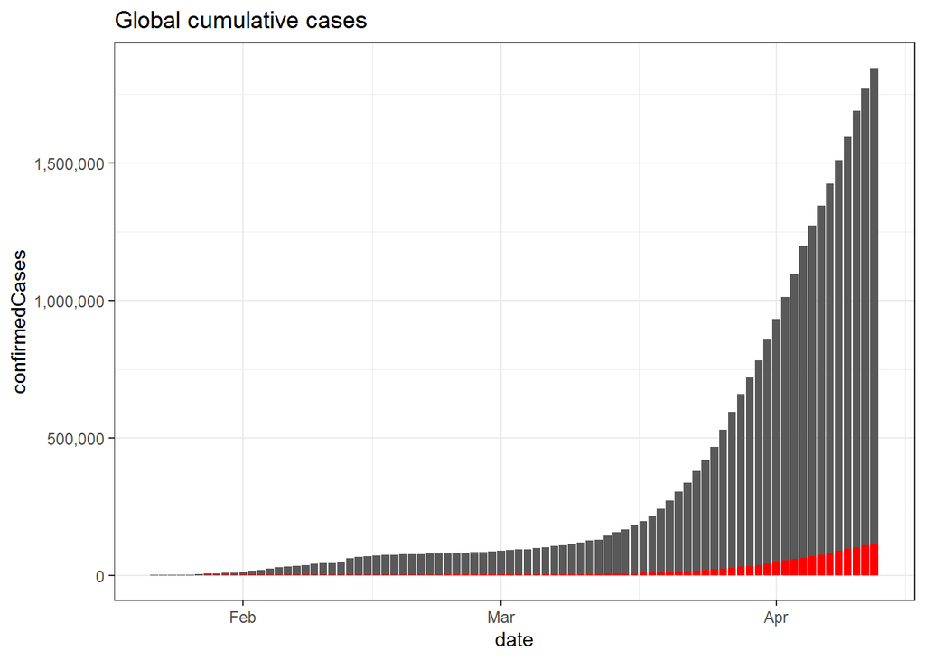

```r
#Plot the cases and deaths over time
ggplot(data=covid19)+
  scale_y_continuous(labels = scales::comma)+
  geom_bar(aes(x=date, y=confirmedCases), stat="identity")+
  geom_bar(aes(x=date, y=deaths), stat="identity", fill="red")+
  theme_bw()+
  ggtitle("Global cumulative cases")
```

#### add in population data from gapminder

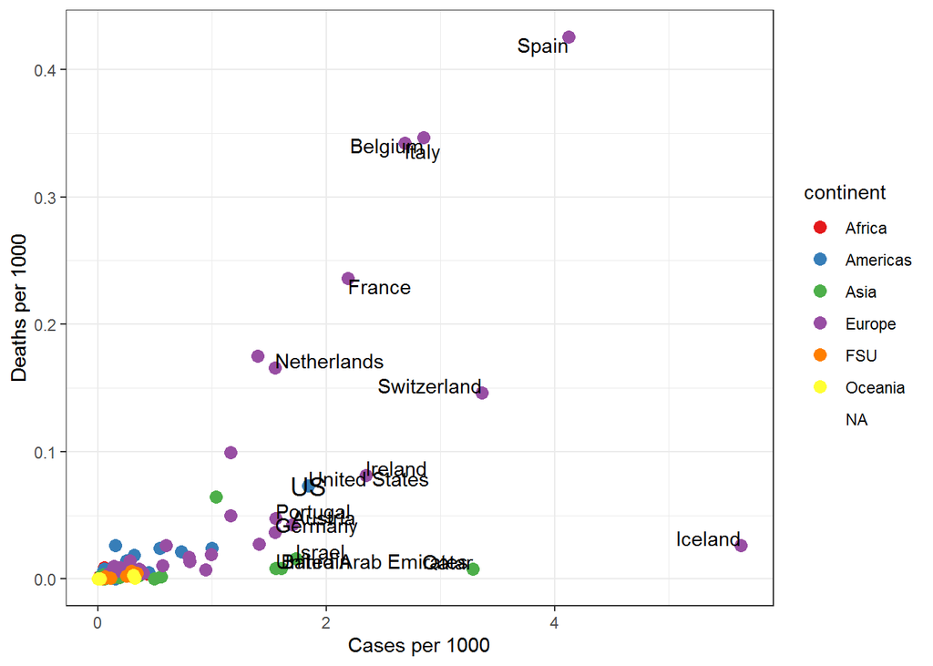

```r
data("gapminder_unfiltered")


covid19 <- left_join(covid19, gapminder_unfiltered[gapminder_unfiltered$year=="2007",], by = c("Country.Region" = "country"))

todayscovid19 <- covid19 %>%
    filter(date==max(date)) %>%
    group_by(continent, Country.Region, pop)%>%
    summarise(confirmedCases = sum(confirmedCases),
              deaths = sum(deaths))

ggplot(todayscovid19, aes(x=confirmedCases*1000/pop, y=deaths*1000/pop, color=continent))+
    geom_point(size=3)+
    theme_bw()+
    scale_color_brewer(palette="Set1")+
    geom_text(data=subset(todayscovid19, confirmedCases*1000/pop > 1.50),
              aes(x=confirmedCases*1000/pop, y=deaths*1000/pop,label=Country.Region), vjust="inward", hjust="inward", color="Black")+
    labs(x="Cases per 1000", y="Deaths per 1000")+
    geom_text(data=subset(todayscovid19, Country.Region == "United States"),
               aes(x=confirmedCases*1000/pop, y=deaths*1000/pop, label="US"), size=5, color="black")
```

```r
  # geom_text(data=subset(todayscovid19, Country.Region == "India"),
               # aes(x=confirmedCases*1000/pop, y=deaths*1000/pop, label="India"), size=5, color="black")
ggsave(file=paste0("PerCapitaCasesDeaths", format(Sys.Date(), "%B%d"), ".jpg"))
```

### Global Cases and Deaths per capita through time

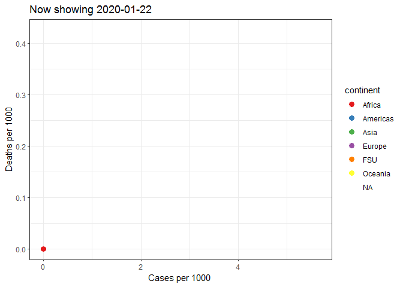

```r
### lets see if I can animate by day, this works but the text is all over the place, turning that off for now

anim <- ggplot(covid19, aes(x=confirmedCases*1000/pop, y=deaths*1000/pop, color=continent))+
    geom_point(size=3)+
    theme_bw()+
    scale_color_brewer(palette="Set1")+
    # geom_text(data=subset(covid19, confirmedCases*1000/pop > .15),
              # aes(x=confirmedCases*1000/pop, y=deaths*1000/pop,label=Country.Region), vjust="inward", hjust="inward", color="Black")+
    labs(x="Cases per 1000 ", y="Deaths per 1000")+
    # geom_text(data=subset(covid19, Country.Region == "United States"),
               # aes(x=confirmedCases*1000/pop, y=deaths*1000/pop, label="US"), size=5, color="black")+
    transition_time(time=covid19$date)+
    ggtitle('Now showing {frame_time}')
animate(anim, renderer = gifski_renderer(), end_pause = 15)
```

```r
anim_save(filename="casesDeathsPerCapita.gif", animation=last_animation())
```

#### Kid1 summary data for the US and Canada

I started working on this becasue Kid1 wanted the numbers for the US and Canada each day. You can chain together all commands and not make an object of just the US and Canada, but I like to check that I’ve changed the data the way I think I’m changing the data

```r
#check spelling/caps for countries
# levels(as.factor(cases$Country.Region))
usCanada <- covid19 %>%
  filter(Country.Region %in% c("United States", "Canada")) %>%
  droplevels() %>%
  group_by(date, Country.Region) %>%
  summarise(confirmedCases = sum(confirmedCases),
                 deaths = sum(deaths))
```

Write this daily data to a csv for Kid1 to open and paste into excel because he isn’t interested in learning R yet.

```r
write.csv(usCanada, file=paste0("usCanadaDaily", format(Sys.Date(),"%B%d"),".csv"))
```

I can’t help but make a graph for him as well, because seeing data is fundimental to understanding the numbers

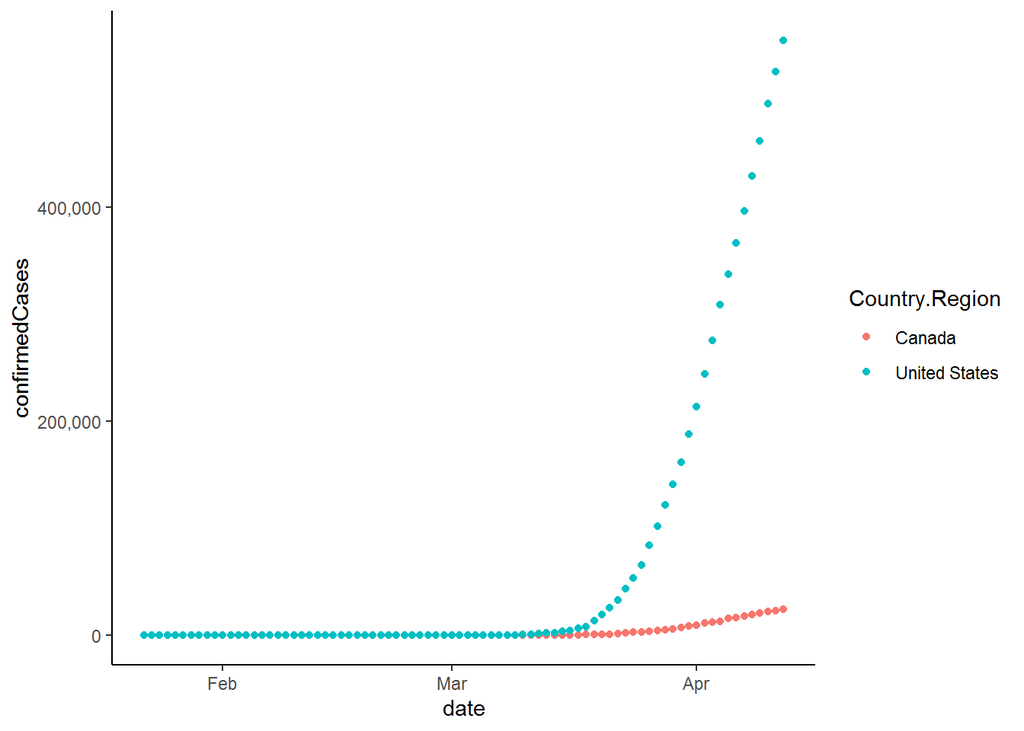

```r
ggplot(usCanada, aes(x=date, y=confirmedCases, color=Country.Region))+
    scale_y_continuous(labels = scales::comma)+
  geom_point()+
  theme_classic()
```

Making the data fully tidy allows for other visualizations

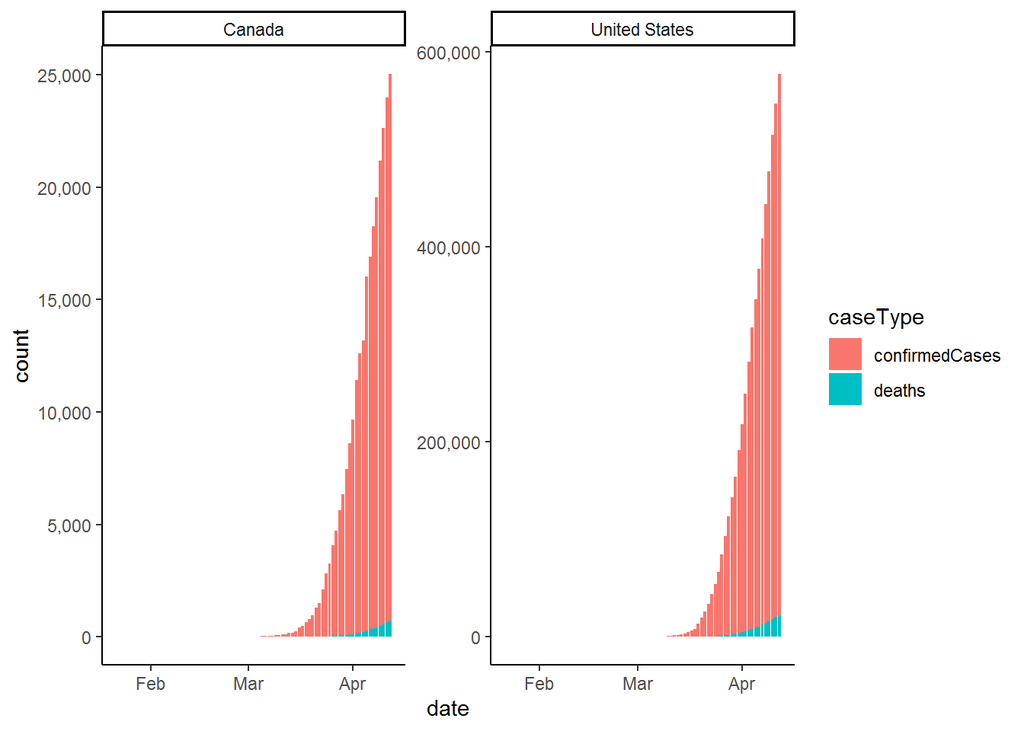

```r
usCanadaLong <- pivot_longer(usCanada, -c(date, Country.Region), names_to="caseType", values_to = "count")
ggplot(usCanadaLong, aes(x=date, y=count, fill=caseType))+
  geom_bar(stat="identity")+
  scale_y_continuous(labels = scales::comma)+
  facet_wrap(vars(Country.Region), scales = "free_y")+
  theme_classic()
```

## US testing numbers compiled by Covid Project

The lack of testing in the US is a critical concern in stopping the spread of the virus. And it’s personally/professionally interesting because qPCR is something that we do in (MARS)[https://mars.uconn.edu] often. The (Covid Tracking Project)[https://covidtracking.com] is trying to compile all testing data, not just positives from each state.

```r
# Read in current  data
usDaily <- read.csv("https://covidtracking.com/api/states/daily.csv", header=T)
usDaily$date <- as.Date(as.character(usDaily$date), format="%Y%m%d")

# read in US population data
usPop <- read.csv("https://www2.census.gov/programs-surveys/popest/datasets/2010-2019/state/detail/SCPRC-EST2019-18+POP-RES.csv", header=T)

# CovidProject has states 2 letter abbreviation. The census has states spelled out. We need a linker file.

usAbb <- read.csv("https://raw.githubusercontent.com/jasonong/List-of-US-States/master/states.csv", header=T, stringsAsFactors = F)

usPop <- left_join(usPop, usAbb, by=c("NAME" = "State"))

# Puerto Rico isn't listed correctly, just going to fix manually

usPop[usPop$NAME == "Puerto Rico Commonwealth", "Abbreviation"] <- "PR"

# regions and divisions are numberic rather than words

usPop$REGION <- recode(usPop$REGION,
  "0" = "US",
  "1" = "Northeast",
  "2" = "Midwest",
  "3" = "South",
  "4" = "West",
  "X" = "Puerto Rico"
)

usPop$DIVISION <- recode(usPop$DIVISION,
                         "0" = "US",
                         "1" = "New England",
                         "2" = "Middle Atlantic",
                         "3" = "East North Central",
                         "4" = "West North Central",
                         "5" = "South Atlantic",
                         "6" = "East South Central",
                         "7" = "West South Central",
                         "8" = "Mountain",
                         "9" = "Pacific",
                         "X" = "Puerto Rico" )

# add Puerto Rico to geofacet
my_gird <- us_state_grid1 %>% add_row(row=6, col=11, code="PR",name="Puerto Rico")
```

#### Positive and per capita rate

Calculate the positive rate which is important for determining how prevelant cases are in the community.

```r
usDaily$posRate <- usDaily$positive/usDaily$total

usDailyAll <- left_join(usDaily, usPop, by=c("state" = "Abbreviation")) %>%
    mutate(posTotalPerCap = (positive*1000)/POPESTIMATE2019,
           negTotalPerCap = (negative*1000)/POPESTIMATE2019,
           hospTotalPerCap = (hospitalized*1000)/POPESTIMATE2019,
           deathTotalPerCap = (death*1000)/POPESTIMATE2019,
           totalTotalPerCap = (total*1000)/POPESTIMATE2019,
        deathPerCap = (deathIncrease*1000)/POPESTIMATE2019,
           hospitalizedPerCap = (hospitalizedIncrease*1000)/POPESTIMATE2019,
           positivePerCap = (positiveIncrease*1000)/POPESTIMATE2019,
            testsPerCap = (totalTestResultsIncrease*1000)/POPESTIMATE2019)

usDailyAll$REGION <- droplevels(usDailyAll$REGION)
usDailyAll$DIVISION <- droplevels(usDailyAll$DIVISION)
```

We’ll tidy the Covid Project data so we can plot it .

```r
usDailyIncrease <- usDailyAll %>%
  select(c(date, state, deathIncrease, hospitalizedIncrease, negativeIncrease, positiveIncrease, totalTestResultsIncrease))


usDaily <- usDailyAll %>%
  select(c(date, state, positive, negative, hospitalized, death, posRate, total))

usDailyLong <- pivot_longer(usDaily, -c(date, state), names_to = "testType", values_to = "count")

# Again, I could do this filtering before each plot or I can make a separate object. I'm the new opject kind of R person.

usDailyLongNoTotal <- usDailyLong %>%
  filter(testType %in% c("negative", "pending", "positive", "hospitalized", "death"))

# I want to set the order to display the results
usDailyLongNoTotal$testType <- factor(usDailyLongNoTotal$testType, levels = c("negative", "pending", "positive", "hospitalized", "death"))

# Also, want to set the color for each result type
testType.col <- c("negative" = "grey",
                  "pending" = "lightgrey",
                  "positive" = "red",
                  "hospitalized" = "purple",
                  "death" = "black")
```

#### Plot the total tests and their outcomes

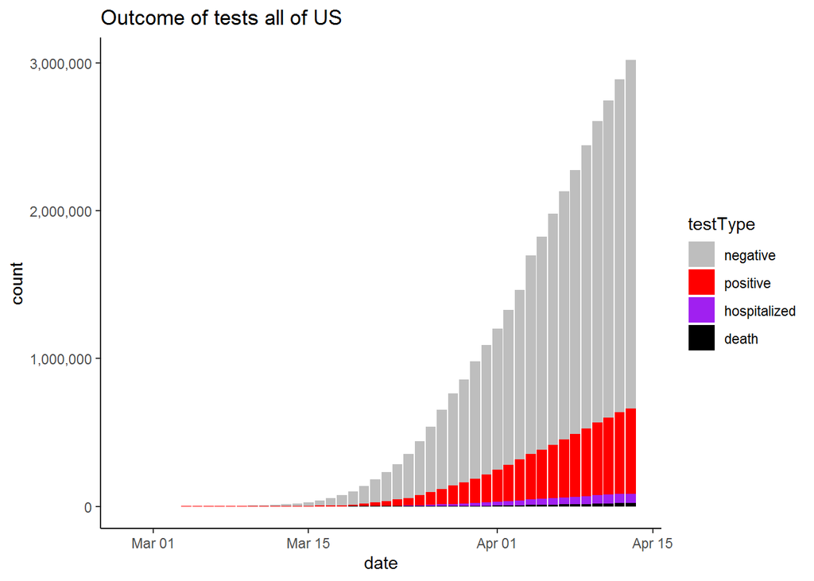

```r
ggplot(usDailyLongNoTotal)+
  geom_bar(stat="identity", aes(x=date, y=count,fill=testType))+
  scale_fill_manual(values=testType.col)+
  # scale_y_log10()+
  theme_classic()+
  scale_y_continuous(labels = scales::comma)+
  ggtitle("Outcome of tests all of US")
```

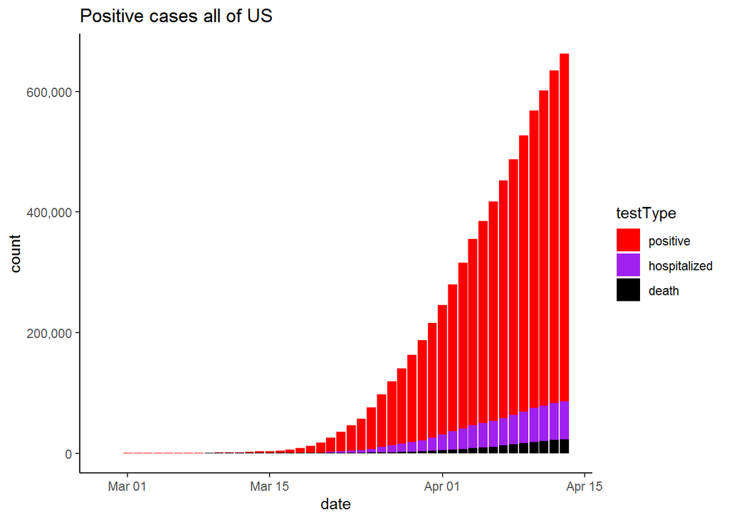

```r
usDailyLongNoTotal%>%
  filter(testType %in% c("positive", "hospitalized", "death"))%>%
ggplot()+
  geom_bar(stat="identity", aes(x=date, y=count,fill=testType))+
  scale_fill_manual(values=testType.col)+
  scale_y_continuous(labels = scales::comma)+
  theme_classic()+
  ggtitle("Positive cases all of US")
```

Total tests adminstered by each state.

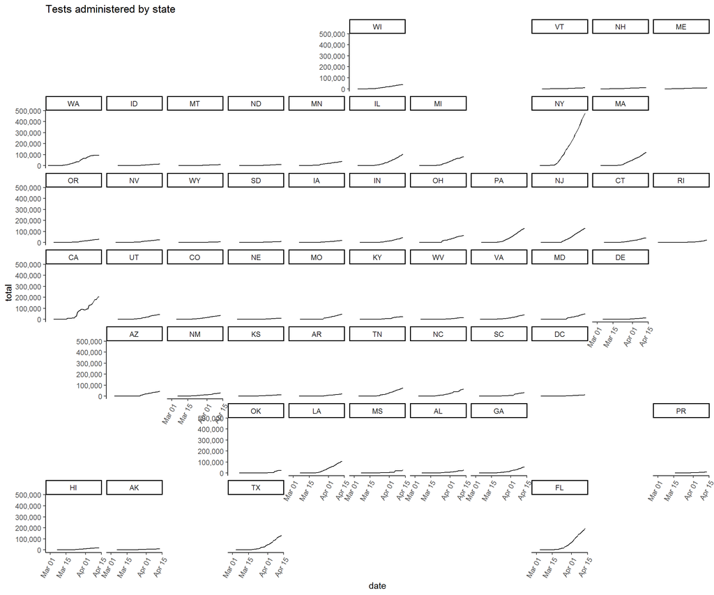

```r
ggplot(usDaily, aes(x=date, y=total))+
  geom_line()+
  # facet_wrap(~state)+ #wraping by state name
  facet_geo(~state, grid=my_gird)+ #wraping by state location
  # scale_y_log10()+
    scale_y_continuous(labels = scales::comma)+
  theme_classic()+
  theme(axis.text.x = element_text(angle = 60, hjust = 1))+
  ggtitle("Tests administered by state")
```

Testing is very patchy by state, so lets look at the positive rate through time for each state

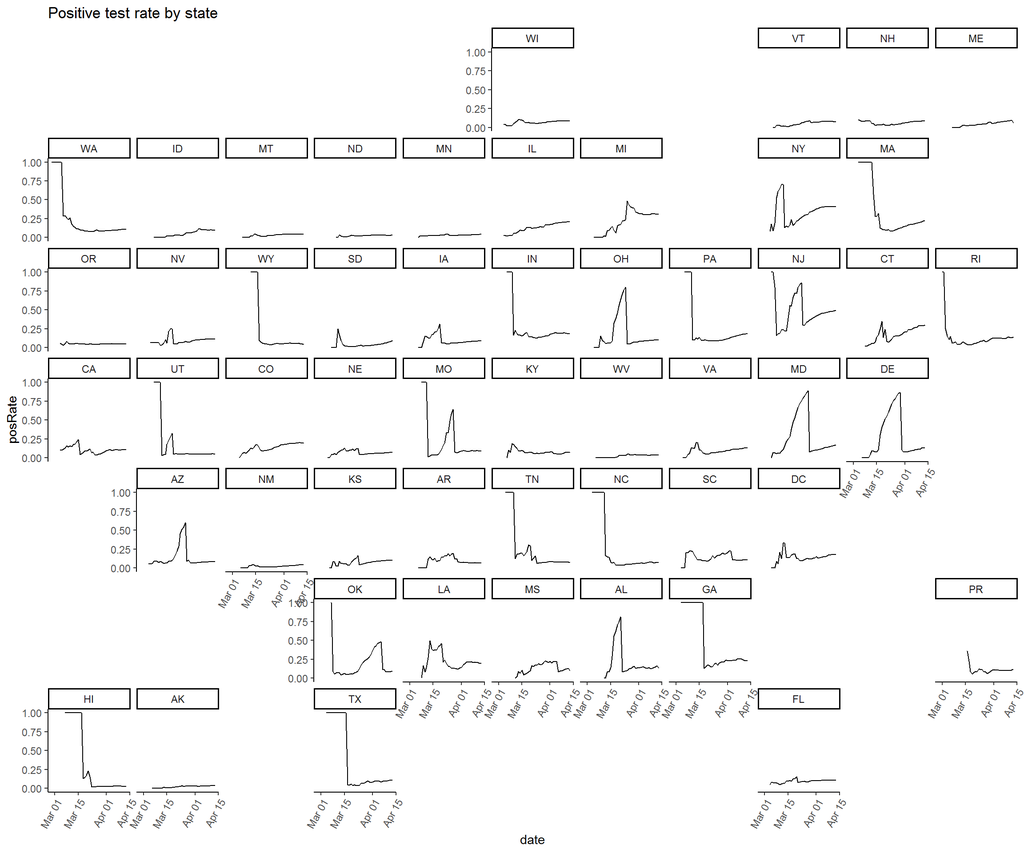

```r
ggplot(usDaily, aes(x=date, y=posRate))+
  geom_line()+
  # facet_wrap(~state)+ #wraping by state name
 facet_geo(~state, grid=my_gird)+ #wraping by state location
  theme_classic()+
  scale_y_continuous(labels = scales::comma)+
  theme(axis.text.x = element_text(angle = 60, hjust = 1))+
  ggtitle("Positive test rate by state")
```

### Plot per capita testing rates by state

It’s hard to compare raw numbers of tests because of different population sizes in each state. So lets calculate tests and positives per capita as permil (1‰ is 1 in 1000, as compared to 1% is 1 in 100)

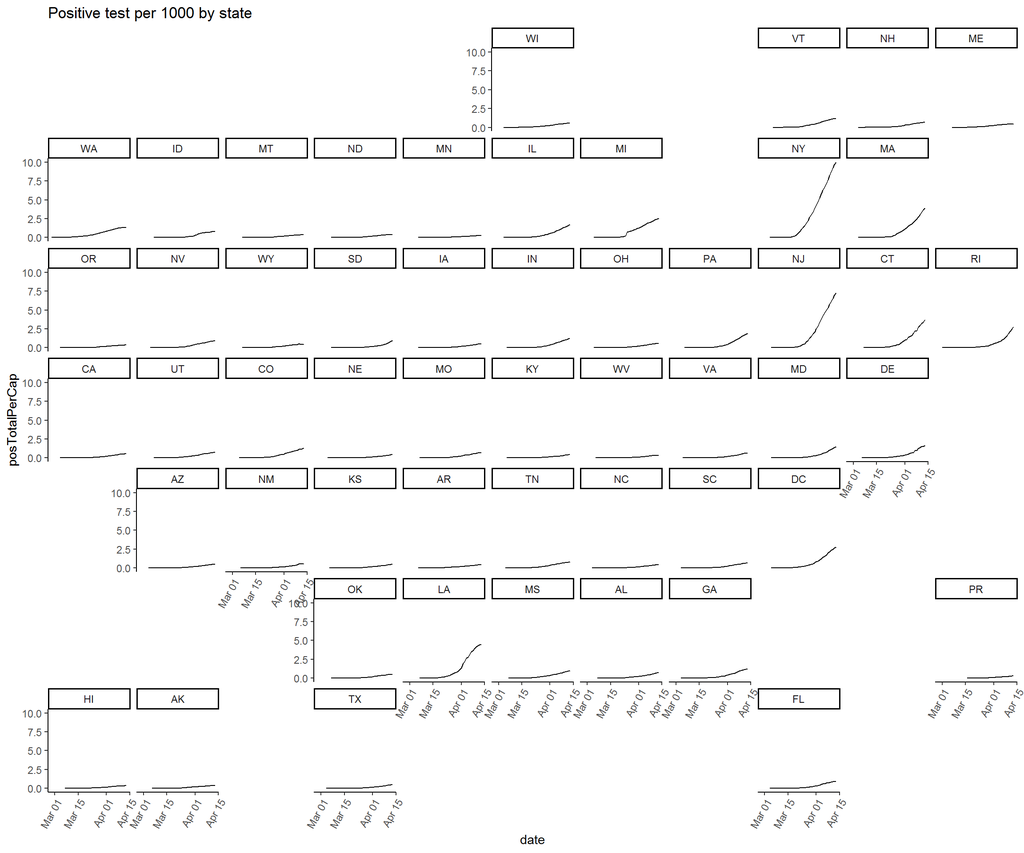

```r
ggplot(usDailyAll, aes(x=date, y=posTotalPerCap))+
  geom_line()+
  # facet_wrap(~state)+ #wraping by state name
 facet_geo(~state, grid=my_gird)+ #wraping by state location
  theme_classic()+
  scale_y_continuous(labels = scales::comma)+
  theme(axis.text.x = element_text(angle = 60, hjust = 1))+
  ggtitle("Positive test per 1000 by state")
```

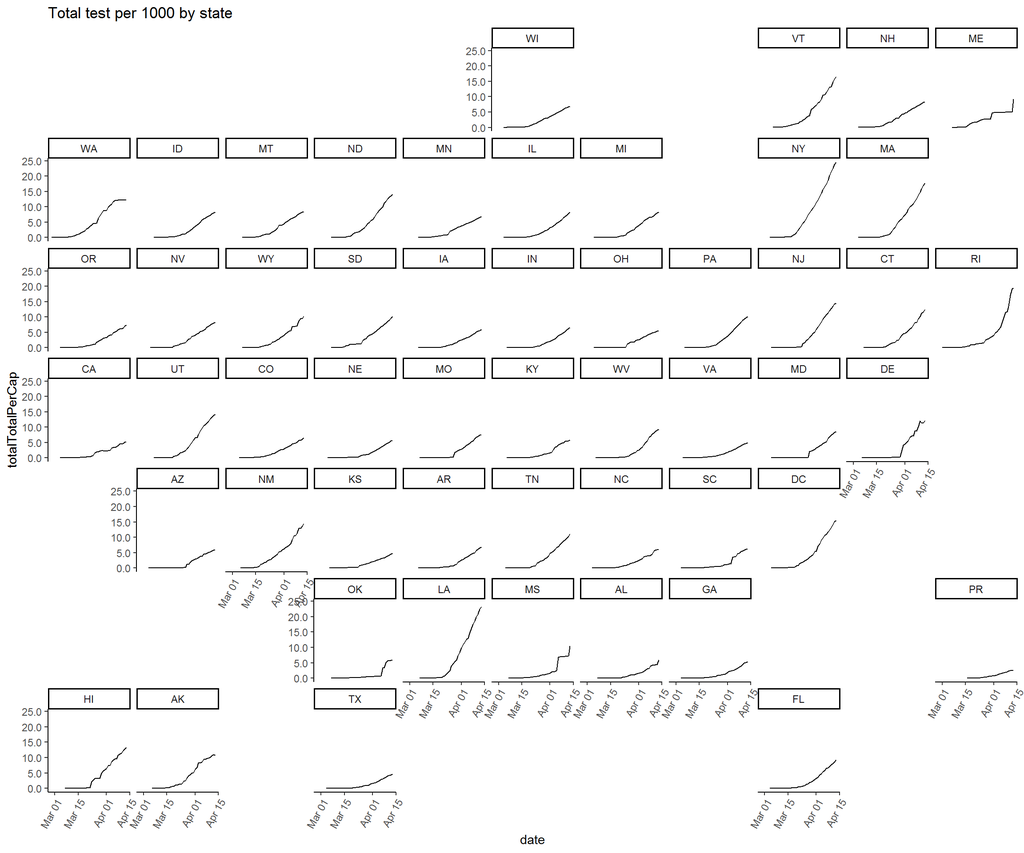

```r
ggplot(usDailyAll, aes(x=date, y=totalTotalPerCap))+
  geom_line()+
  # facet_wrap(~state)+ #wraping by state name
 facet_geo(~state, grid=my_gird)+ #wraping by state location
  theme_classic()+
  scale_y_continuous(labels = scales::comma)+
  theme(axis.text.x = element_text(angle = 60, hjust = 1))+
  ggtitle("Total test per 1000 by state")
```

```r
ggsave(filename = "perCapitaTotalTests.jpg")
```

### Cases and deaths per capita through time

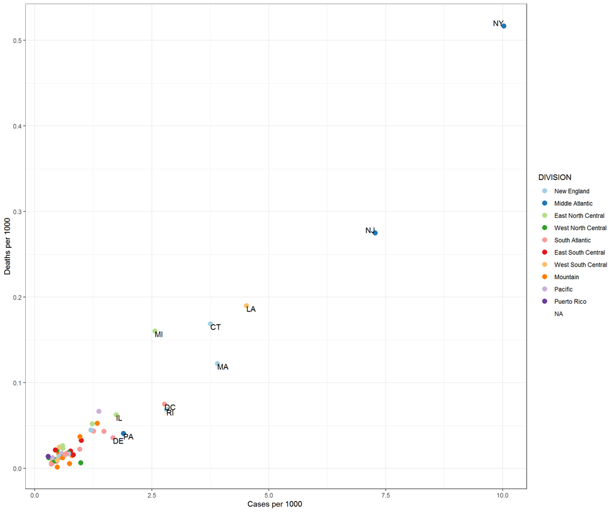

```r
usToday <- usDailyAll %>%
  filter(date==max(date))

ggplot(usToday, aes(x=posTotalPerCap, y=deathTotalPerCap, color=DIVISION))+
    geom_point(size=3)+
    theme_bw()+
    scale_color_brewer(palette="Paired")+
    geom_text(data=subset(usToday, posTotalPerCap > 1.5),
              aes(x=posTotalPerCap, y=deathTotalPerCap,label=state),  vjust="outward", hjust="inward",color="Black")+
  labs(x="Cases per 1000 ", y="Deaths per 1000")
```

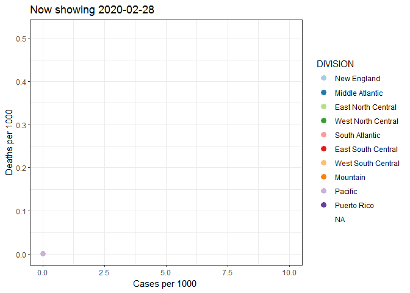

```r
ggsave("casesDeathsPerCapita.jpg", width = 8, height=5)

anim <- ggplot(usDailyAll, aes(x=posTotalPerCap, y=deathTotalPerCap, color=DIVISION))+
    geom_point(size=3)+
    theme_bw()+
    scale_color_brewer(palette="Paired")+
    # geom_text(data=subset(usDailyAll, posTotalPerCap > 1.5),
              # aes(x=posTotalPerCap, y=deathTotalPerCap,label=NAME), vjust="inward", hjust="inward", color="Black")+
  labs(x="Cases per 1000 ", y="Deaths per 1000")+
    transition_time(time=usDailyAll$date)+
    ggtitle('Now showing {frame_time}')
animate(anim, renderer = gifski_renderer(), end_pause = 25)
```

```r
anim_save(filename="casesDeathsPerCapitaUSregion.gif", animation=last_animation())
```

### What about case fatality rate?

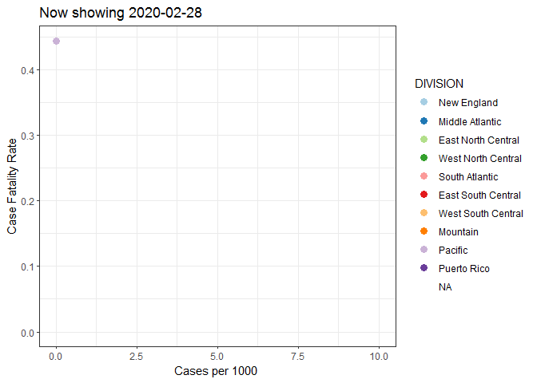

```r
anim <- ggplot(usDailyAll, aes(x=posTotalPerCap, y=death/positive, color=DIVISION))+
    geom_point(size=3)+
    theme_bw()+
    scale_color_brewer(palette="Paired")+
    # geom_text(data=subset(usDailyAll, posTotalPerCap > 1.5),
              # aes(x=posTotalPerCap, y=deathTotalPerCap,label=NAME), vjust="inward", hjust="inward", color="Black")+
  labs(x="Cases per 1000 ", y="Case Fatality Rate")+
    # geom_text(data=subset(covid19, Country.Region == "United States"),
               # aes(x=confirmedCases*1000/pop, y=deaths*1000/pop, label="US"), size=5, color="black")+
    transition_time(time=usDailyAll$date)+
    ggtitle('Now showing {frame_time}')
animate(anim, renderer = gifski_renderer(), end_pause = 25)
```

```r
anim_save(filename="CFRtime.gif", animation=last_animation())
```

#### Plotting the increases

We are still under testing, looking at the increases in tests and positives each day can help demonstrate that.

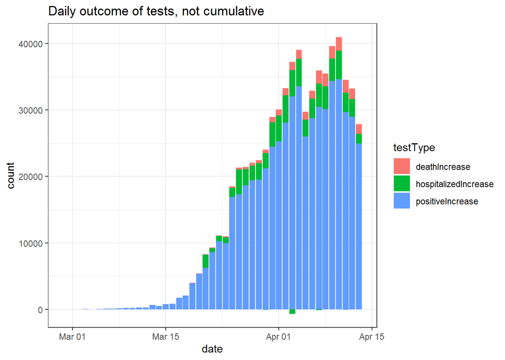

```r
usDailyIncreaselong<- usDailyIncrease%>%
  pivot_longer(-c(date, state), names_to = "testType", values_to = "count")%>%
  filter(testType %in% c("deathIncrease", "positiveIncrease", "hospitalizedIncrease"))
usTotalsIncrease <- usDailyIncrease%>%
  group_by(date)%>%
  summarise(deathIn = sum(deathIncrease),
            hospitalizedIn = sum(hospitalizedIncrease),
            positiveIn = sum(positiveIncrease),
            negativeIn = sum(negativeIncrease),
            totalTestIn = sum(totalTestResultsIncrease))

ggplot()+
  geom_bar(data=usDailyIncreaselong,stat="identity", aes(x=date, y=count,fill=testType))+
  # scale_fill_manual(values=testType.col)+
  theme_bw()+
  ggtitle("Daily outcome of tests, not cumulative")
```

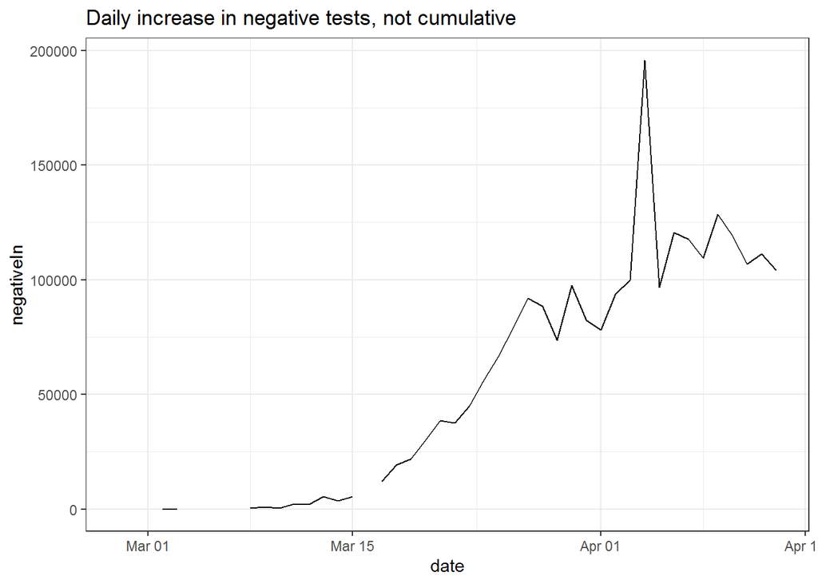

```r
ggplot(data=usTotalsIncrease, aes(x=date, y=negativeIn))+
  geom_line()+
  theme_bw()+
  ggtitle("Daily increase in negative tests, not cumulative")
```

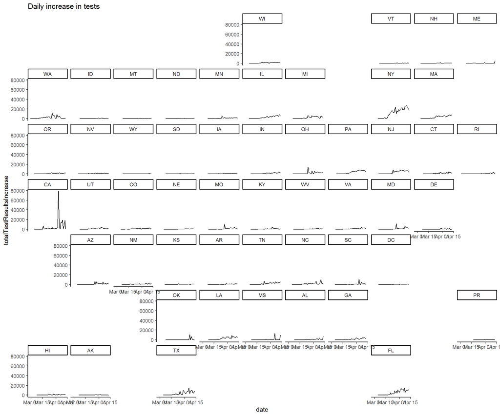

```r
ggplot(usDailyIncrease)+
  geom_line(aes(x=date, y=totalTestResultsIncrease))+
  # facet_wrap(~state)+ #wraping by state name
 facet_geo(~state, grid=my_gird)+ #wraping by state location
  theme_classic()+
  # scale_y_log10()+
  ggtitle("Daily increase in tests")
```

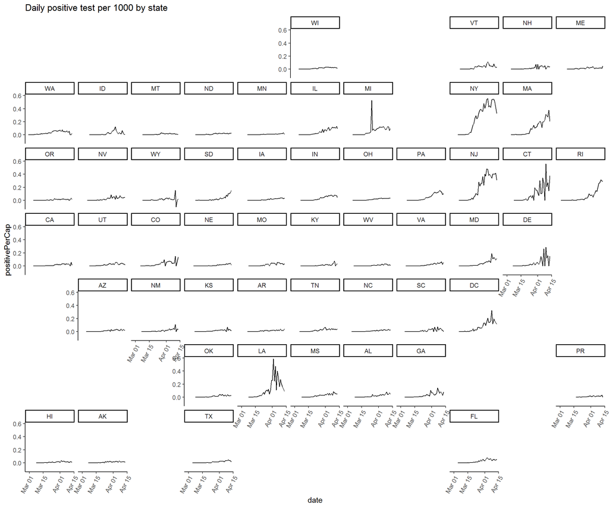

```r
usIncPop <- left_join(usDailyIncrease, usPop, by=c("state" = "Abbreviation")) %>%
    mutate(deathPerCap = (deathIncrease*1000)/POPESTIMATE2019,
           hospitalizedPerCap = (hospitalizedIncrease*1000)/POPESTIMATE2019,
           positivePerCap = (positiveIncrease*1000)/POPESTIMATE2019,
            testsPerCap = (totalTestResultsIncrease*1000)/POPESTIMATE2019)



ggplot(usIncPop, aes(x=date, y=positivePerCap))+
  geom_line()+
  # facet_wrap(~state)+ #wraping by state name
 facet_geo(~state, grid=my_gird)+ #wraping by state location
  theme_classic()+
  theme(axis.text.x = element_text(angle = 60, hjust = 1))+
  ggtitle("Daily positive test per 1000 by state")
```

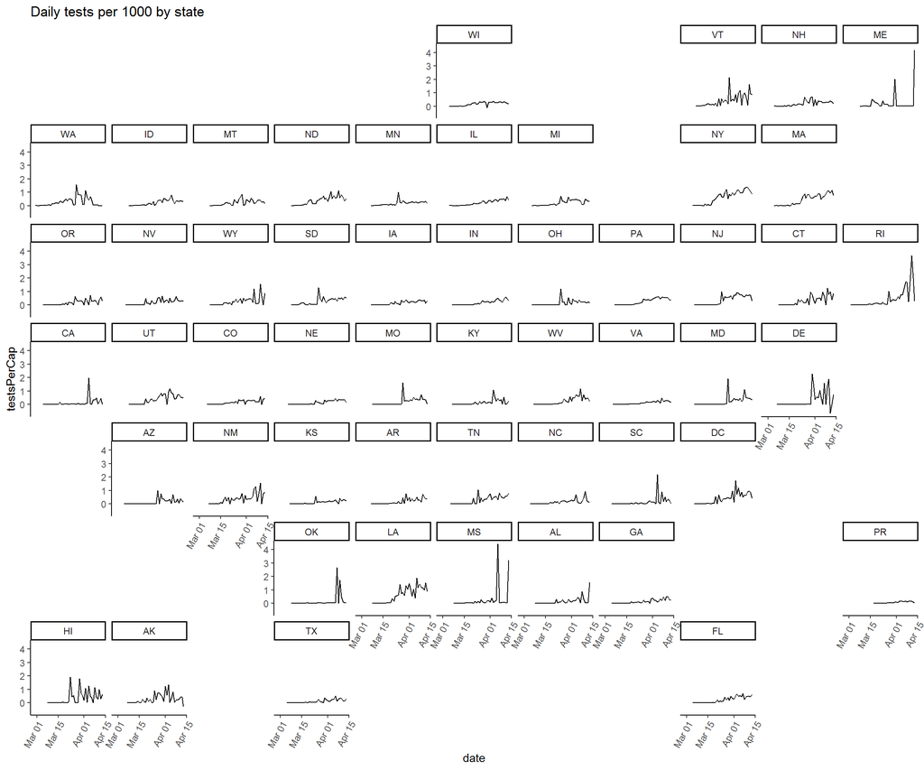

```r
ggsave("DailyPosPerCapitaState.jpg", width=10, height=8)

ggplot(usIncPop, aes(x=date, y=testsPerCap))+
  geom_line()+
  # facet_wrap(~state)+ #wraping by state name
 facet_geo(~state, grid=my_gird)+ #wraping by state location
  theme_classic()+
  theme(axis.text.x = element_text(angle = 60, hjust = 1))+
  ggtitle("Daily tests per 1000 by state")
```

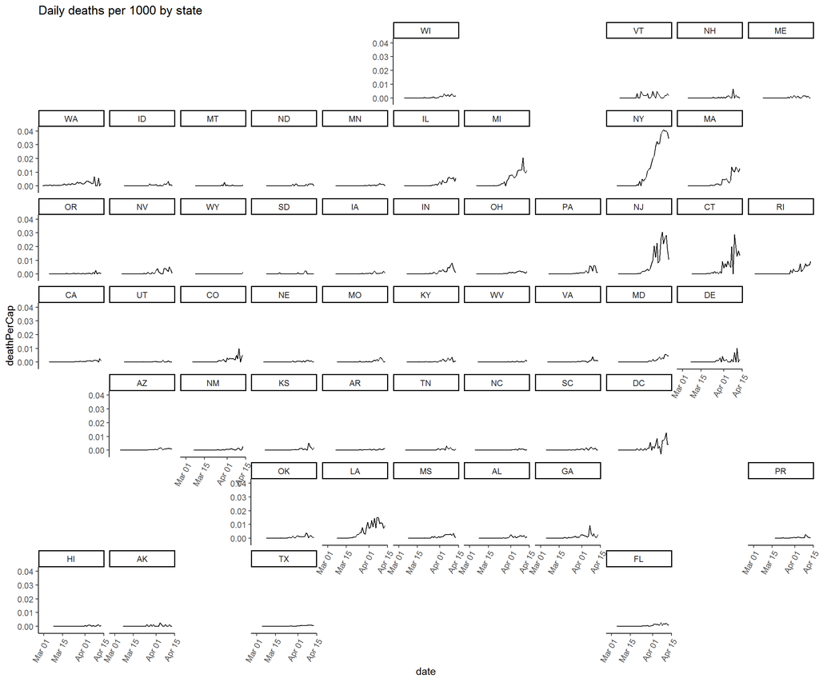

```r
ggsave("DailyTestsPerCapitaState.jpg", width=10, height=8)

ggplot(usIncPop, aes(x=date, y=deathPerCap))+
  geom_line()+
  # facet_wrap(~state)+ #wraping by state name
 facet_geo(~state, grid=my_gird)+ #wraping by state location
  theme_classic()+
  theme(axis.text.x = element_text(angle = 60, hjust = 1))+
  ggtitle("Daily deaths per 1000 by state")
```

```r
ggsave("DailyDeathsPerCapitaState.jpg", width=10, height=8)
```

### Bringing it home. How is CT doing?

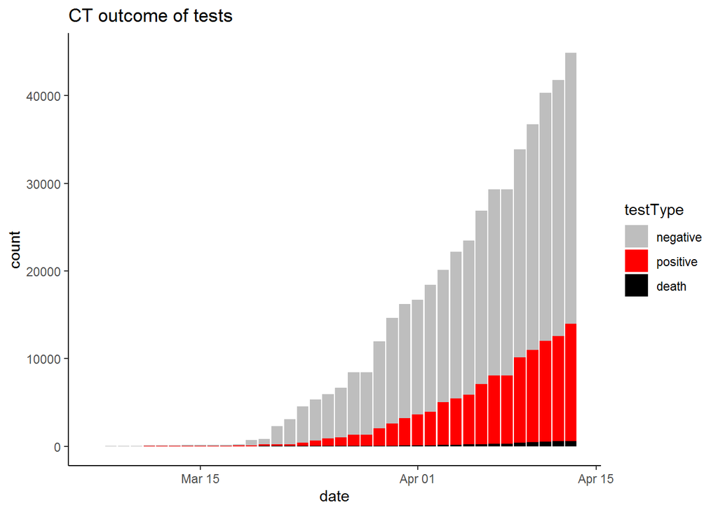

```r
usDailyLongNoTotal %>%
  filter(state == "CT") %>%
ggplot()+
  geom_bar(stat="identity", aes(x=date, y=count,fill=testType))+
  scale_fill_manual(values=testType.col)+
  # scale_y_log10()+
  theme_classic()+
  ggtitle("CT outcome of tests")
```

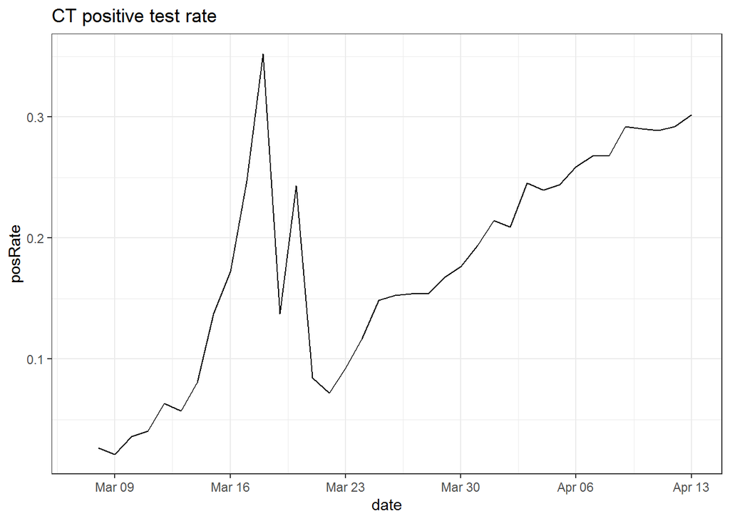

```r
# ggsave(file=paste0("ctTestOutCome", format(Sys.Date(), "%B%d"), ".jpg"))

usDaily %>%
  filter(state == "CT") %>%
  ggplot(aes(x=date, y=posRate))+
  geom_line()+
  theme_bw()+
  ggtitle("CT positive test rate")
```

There was a big spike in positive rate March 18, which means they were only testing people who were likley sick. If we look at total tests administered, there’s been a significant increase in testing since then. But our positive test result (and statements from state public health) tell us that we are still under testing.

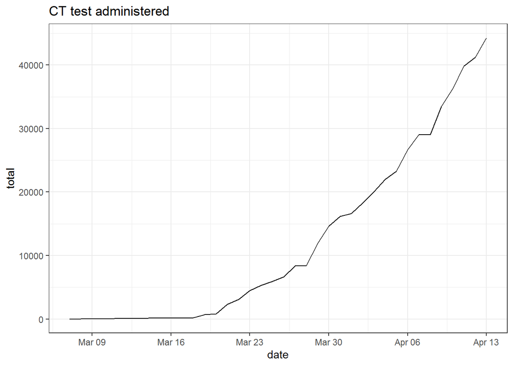

```r
usDaily %>%
  filter(state == "CT") %>%
  ggplot(aes(x=date, y=total))+
  geom_line()+
  theme_bw()+
  ggtitle("CT test administered")
```

## NY Times county data

New York Times has released their data on US cases at the county level.

### Mapping Cases and Deaths by county

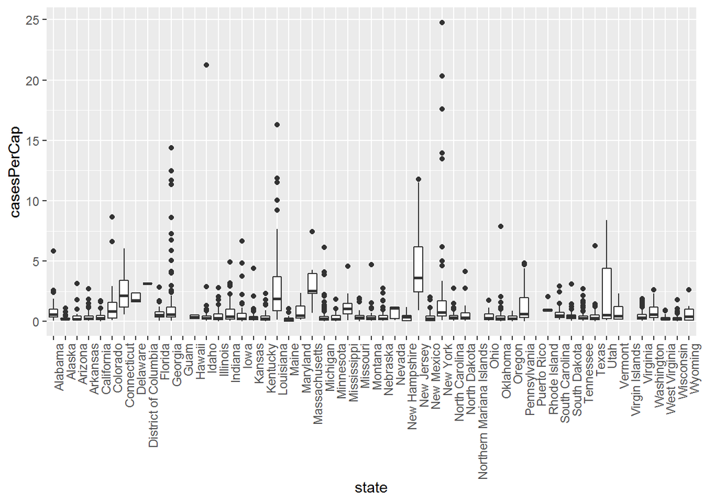

```r
nytcountypop %>%
    filter(date==max(date)) %>%
  ggplot() +
  geom_boxplot(aes(x=state, y=casesPerCap))+
  theme(axis.text.x = element_text(angle = 90, hjust = 1))
```

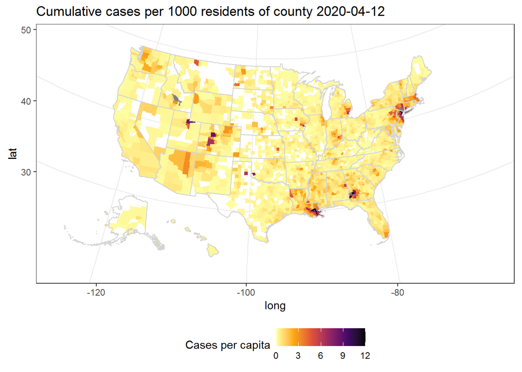

```r
p <- nytcountypop %>%
    filter(date==max(date)) %>%
  ggplot(aes(long, lat, group=group))

p+    geom_polygon(aes(fill=casesPerCap))+
  geom_polygon(data = states, mapping = aes(long, lat, group = group), fill = NA, color = "light grey") +
  scale_fill_viridis_c(option = "inferno",direction = -1, limits = c(0, 12))+
  coord_map(projection = "albers", lat0 = 39, lat1=45)+
  labs(fill="Cases per capita")+
  theme_bw()+
  theme(legend.position = "bottom")+
  ggtitle(paste("Cumulative cases per 1000 residents of county", max(nytcountypop$date)))
```

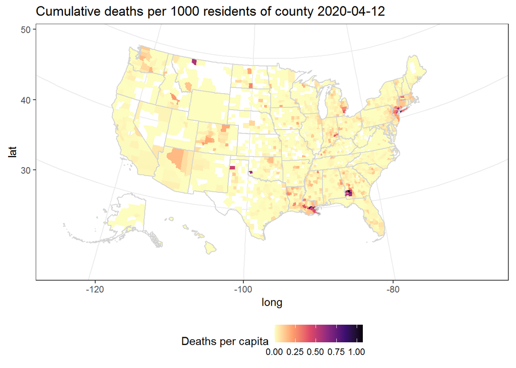

```r
  ggsave("MapCasesPerCapitaCounty.jpg", width = 12, height=12)

p+    geom_polygon(aes(fill=deathsPerCap))+
  geom_polygon(data = states, mapping = aes(long, lat, group = group), fill = NA, color = "light grey") +
  scale_fill_viridis_c(option = "magma",direction = -1)+
  coord_map(projection = "albers", lat0 = 39, lat1=45)+
  labs(fill="Deaths per capita")+
  theme_bw()+
  theme(legend.position = "bottom")+
  ggtitle(paste("Cumulative deaths per 1000 residents of county", max(nytcountypop$date)))
```

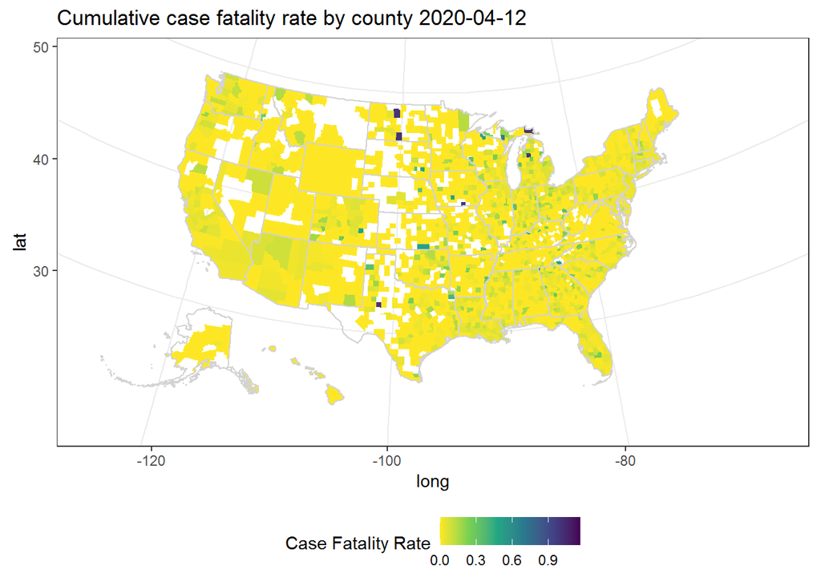

```r
ggsave("MapDeathsPerCapitaCounty.jpg", width = 12, height=12)

p+    geom_polygon(aes(fill=deaths/cases))+
  geom_polygon(data = states, mapping = aes(long, lat, group = group), fill = NA, color = "light grey") +
  scale_fill_viridis_c(option = "viridis",direction = -1)+
  coord_map(projection = "albers", lat0 = 39, lat1=45)+
  labs(fill="Case Fatality Rate")+
  theme_bw()+
  theme(legend.position = "bottom")+
  ggtitle(paste("Cumulative case fatality rate by county", max(nytcountypop$date)))
```

```r
ggsave("MapDeathsPerCaseCounty.jpg", width = 12, height=12)
```

### Case fatality rate as indicator of undertesting

Looking at data from other countries with better testing and who are further into the pandemic than the US, the true case fatality rate seems to be between 0.5-3%. We can use this to map the areas of the country that are still undertesting. We’ll use a really bad, much worse than we think might be true cutoff of 5%.

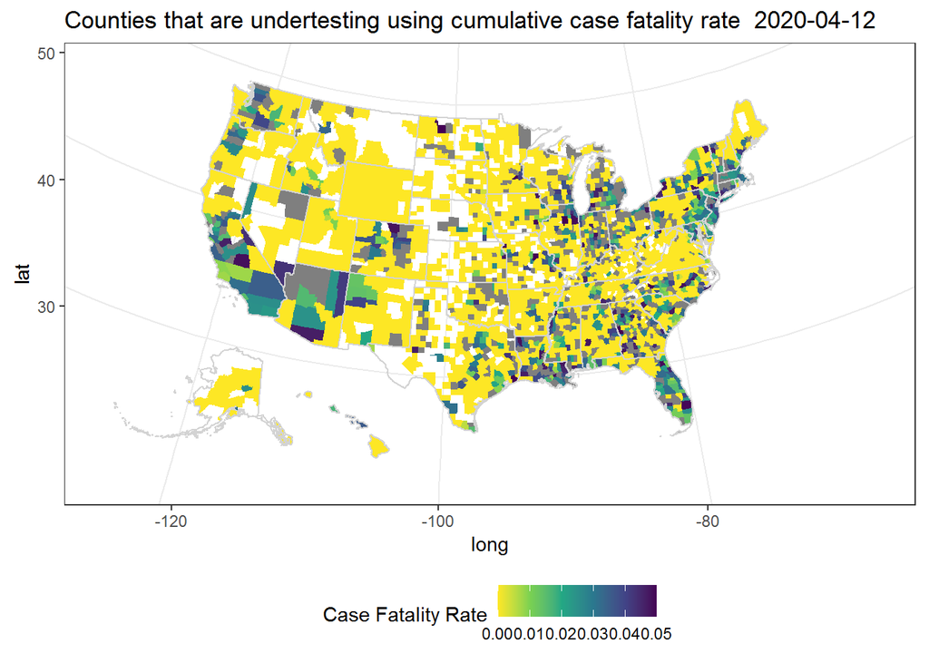

```r
p+    geom_polygon(aes(fill=deaths/cases))+
  geom_polygon(data = states, mapping = aes(long, lat, group = group), fill = NA, color = "light grey") +
  scale_fill_viridis_c(option = "viridis",direction = -1, limits = c(0,.05))+
  coord_map(projection = "albers", lat0 = 39, lat1=45)+
  labs(fill="Case Fatality Rate")+
  theme_bw()+
  theme(legend.position = "bottom")+
  ggtitle(paste("Counties that are undertesting using cumulative case fatality rate ", max(nytcountypop$date)))
```

```r
ggsave("MapDeathsPerCaseCounty.jpg", width = 12, height=12)
```

### animate cases and deaths per capita through time

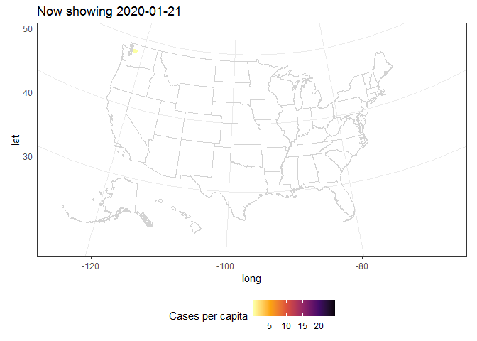

```r
anim <- nytcountypop %>%
  filter(!is.na(casesPerCap)) %>%
  ggplot(aes(long, lat, group= fips))+
  geom_polygon(aes(fill=casesPerCap))+
  geom_polygon(data = states, mapping = aes(long, lat, group = group), fill = NA, color = "light grey") +
  scale_fill_viridis_c(option = "inferno",direction = -1)+
  coord_map(projection = "albers", lat0 = 39, lat1=45)+
  labs(fill="Cases per capita")+
  theme_bw()+
  theme(legend.position = "bottom")+
  transition_time(time=date)+
    ggtitle('Now showing {frame_time}')
animate(anim, renderer = gifski_renderer(), end_pause = 20, fps = 5)
```

```r
anim_save(filename="mapCasesPerCapCounty.gif", animation=last_animation())
```

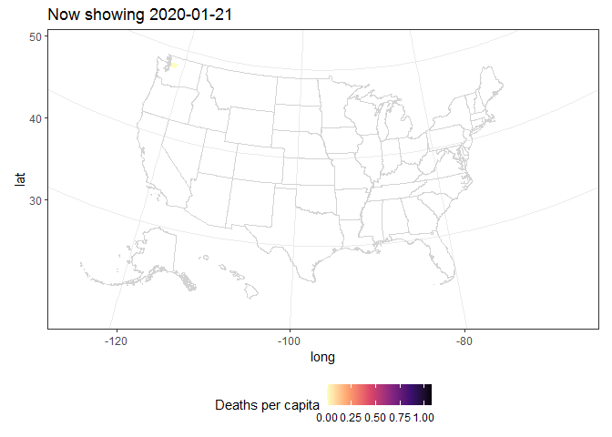

```r
anim <- nytcountypop %>%
  filter(!is.na(deathsPerCap)) %>%
  ggplot(aes(long, lat, group=group))+
  geom_polygon(aes(fill=deathsPerCap))+
  geom_polygon(data = states, mapping = aes(long, lat, group = group), fill = NA, color = "light grey") +
  scale_fill_viridis_c(option = "magma",direction = -1)+
  coord_map(projection = "albers", lat0 = 39, lat1=45)+
  labs(fill="Deaths per capita")+
  theme_bw()+
  theme(legend.position = "bottom")+
  transition_time(time=date)+
    ggtitle('Now showing {frame_time}')
animate(anim, renderer = gifski_renderer(), end_pause = 20, fps = 5)
```

```r
 anim_save(filename="mapDeathsPerCapCounty.gif", animation=last_animation())
```

### Use today’s deaths to calculate 3 weeks ago cases

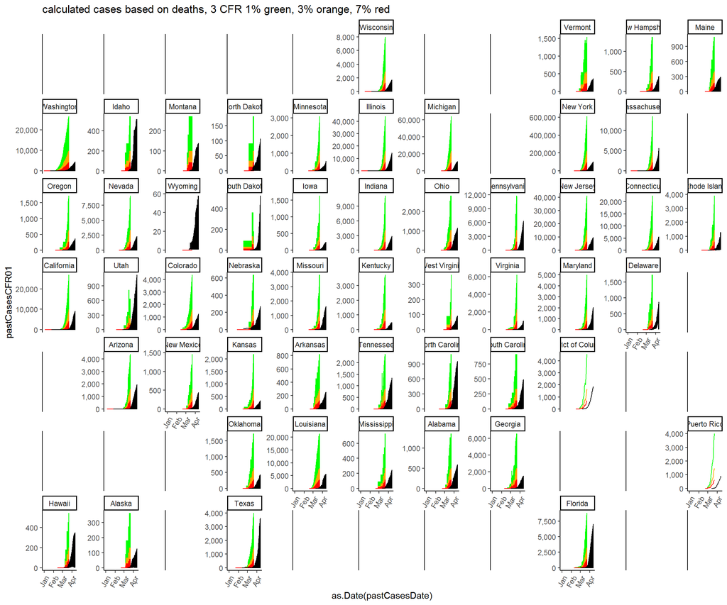

```r
nytcounty$pastCasesDate <- as.Date(as.Date(nytcounty$date) - 21)

# calculate past cases based on deaths, using 1.1% (Diamond Princess), 3% (China), and 7% (Spain/Italy)  CFR
nytcounty$pastCasesCFR01 <- nytcounty$deaths/0.011

nytcounty$pastCasesCFR03 <- nytcounty$deaths/0.03

nytcounty$pastCasesCFR07 <- nytcounty$deaths/0.07



ggplot(data = nytcounty) +
  geom_line(aes(x=as.Date(pastCasesDate), y=pastCasesCFR01), color = "green")+
  geom_line(aes(x=as.Date(pastCasesDate), y=pastCasesCFR03), color = "orange")+
  geom_line(aes(x=as.Date(pastCasesDate), y=pastCasesCFR07), color = "red")+
    geom_line(aes(x = as.Date(date), y = cases), color = "black")+
  facet_geo(~state, grid=my_gird, scales="free_y")+ #wraping by state location
    scale_y_continuous(labels = scales::comma)+
  theme_classic()+
  theme(axis.text.x = element_text(angle = 60, hjust = 1))+
  ggtitle("calculated cases based on deaths, 3 CFR 1% green, 3% orange, 7% red")
```

```r
ggsave("estCasesByState.jpg", width = 20, height = 12)
```

This map/graph shows official, detected cases in black. Then I used deaths to calculate cases in the past using 3 different case fatality rates (1% Diamond Princess, 3% China, 7% Spain/Italy). Since it take people ~3 weeks to die from Covid19, we can calculate back that for every death today, there were 100 or 33 or 14 cases 3 weeks ago depending on what CFR we use. I"m sure there is a much better way to display this.